# BikeSharingAnalysis

Sakava Kiv and Derek Rogers

2024-04-17

Video giving a brief overview of the project: https://youtu.be/-8qr3vHpIak

Project Repo: https://github.com/DotSumWedge/BikeSharingTimeSeriesAnalysis

```r
library(tswge)
library(PolynomF)
library(tidyverse)
library(GGally)
library(astsa)
library(vars)
library(nnfor)
```

```r
library(dplyr)
library(tidyr)
library(ggplot2)
library(plotly)
# Set the working directory to the specified path
#setwd("C:/SMU MS Data Science/TimeSeries/FinalProject/BikeSharingTimeSeriesAnalysis")

# Check to confirm that the working directory has been set correctly
#getwd()
```

This dataset can be used to forecast demand to avoid oversupply and shortages. It spans from January 1, 2011, until December 31, 2018. Determining new station locations, analyzing movement patterns or planning routes will only be possible with additional data.

date - date with the format yyyy-mm-dd temp_avg - average daily temperature in degree Celsius temp_min - minimum daily temperature in degree Celsius temp_max - maximum daily temperature in degree Celsius temp_observ - temperature at the time of observation in degree Celsius precip - amount of precipitation in mm wind - wind speed in meters per second wt_fog - weather type fog, ice fog, or freezing fog (may include heavy fog) wt_heavy_fog - weather type heavy fog or heaving freezing fog (not always distinguished from fog) wt_thunder - weather type thunder wt_sleet - weather type ice pellets, sleet, snow pellets, or small hail wt_hail - weather type hail (may include small hail) wt_glaze - weather type glaze or rime wt_haze - weather type smoke or haze wt_drift_snow - weather type blowing or drifting snow wt_high_wind - weather type high or damaging winds wt_mist - weather type mist wt_drizzle - weather type drizzle wt_rain - weather type rain (may include freezing rain, drizzle, and freezing drizzle) wt_freeze_rain - weather type freezing rain wt_snow - weather type snow, snow pellets, snow grains, or ice crystals wt_ground_fog - weather type ground fog wt_ice_fog - weather type ice fog or freezing fog wt_freeze_drizzle - weather type freezing drizzle wt_unknown - weather type unknown source of precipitation casual - number of unregistered customers registered - number of registered customers total_cust - sum of registered and casual customers holiday - indicates whether the day is a holiday or not

Acknowledgements data used to create this dataset was taken from:

Capital Bikeshare for the bike sharing demand, NOAA’s National Climatic Data Center for weather data, DC Department of Human Resources for data on public holidays.

The chosen data set is the bike_sharing_dataset.csv from kaggle: https://www.kaggle.com/datasets/juliajemals/bike-sharing-washington-dc

The chosen response (target) variable is total_cust

Being able to model and predict total_cust can help entities directly involved or adjacent to bike sharing better understand and predict the varying demand to avoid oversupply or shortages. Forecasting future demand can help plan bike maintenance as heavily used bikes break down more often. This information can help inform business decisions, setting prices, and creating effective advertisements.

```r
# The chosen data set is the bike_sharing_dataset.csv from kaggle: https://www.kaggle.com/datasets/juliajemals/bike-sharing-washington-dc
# The chosen response variable is total_cust
# Being able to model and predict total_cust can help entities directly involved or adjacent to bike sharing better understand and predict the varying demand to avoid oversupply or shortages. Forecasting future demand can help plan bike maintance as heavily used bikes break down more often. This information can help inform business decisions, setting prices, and creating efective advertisements.

BikeSharing = read.csv("bike_sharing_dataset.csv", header = TRUE)
BikeSharing_train = data.frame(TotalCust = ts(BikeSharing$total_cust))

head(BikeSharing)
```

```
##         date temp_avg  temp_min  temp_max temp_observ     precip  wind wt_fog
## 1 2011-01-01       NA -1.566667 11.973333    2.772727 0.06933333 2.575      1
## 2 2011-01-02       NA  0.880000 13.806667    7.327273 1.03734940 3.925      1
## 3 2011-01-03       NA -3.442857  7.464286   -3.060000 1.87882353 3.625     NA
## 4 2011-01-04       NA -5.957143  4.642857   -3.100000 0.00000000 1.800     NA
## 5 2011-01-05       NA -4.293333  6.113333   -1.772727 0.00000000 2.950     NA
## 6 2011-01-06       NA -4.993333  4.233333   -4.245455 0.00000000 1.600     NA
##   wt_heavy_fog wt_thunder wt_sleet wt_hail wt_glaze wt_haze wt_drift_snow
## 1           NA         NA       NA      NA       NA       1            NA
## 2            1         NA       NA      NA       NA      NA            NA
## 3           NA         NA       NA      NA       NA      NA            NA
## 4           NA         NA       NA      NA       NA      NA            NA
## 5           NA         NA       NA      NA       NA      NA            NA
## 6           NA         NA       NA      NA       NA      NA            NA
##   wt_high_wind wt_mist wt_drizzle wt_rain wt_freeze_rain wt_snow wt_ground_fog
## 1           NA       1         NA       1             NA      NA            NA
## 2           NA       1          1       1             NA      NA            NA
## 3           NA      NA         NA      NA             NA      NA            NA
## 4           NA      NA         NA      NA             NA      NA            NA
## 5           NA      NA         NA      NA             NA      NA            NA
## 6           NA      NA         NA      NA             NA       1            NA
##   wt_ice_fog wt_freeze_drizzle wt_unknown casual registered total_cust holiday
## 1         NA                NA         NA    330        629        959      NA
## 2         NA                NA         NA    130        651        781      NA
## 3         NA                NA         NA    120       1181       1301      NA
## 4         NA                NA         NA    107       1429       1536      NA
## 5         NA                NA         NA     82       1489       1571      NA
## 6         NA                NA         NA     88       1485       1573      NA
```

```r
nrow(BikeSharing)
```

```
## [1] 2922
```

```r
# There are 4 consecutive missing values
which(is.na(BikeSharing$total_cust))
```

```
## [1] 1849 1850 1851 1852
```

## Data Cleaning

```r
# Impute the 4 consecutive missing values with the average of the value before and after the missing values

# Calculate the average of the values at positions 1848 and 1853
average_value = mean(c(BikeSharing$total_cust[1848], BikeSharing$total_cust[1853]), na.rm = TRUE)
average_value
```

```
## [1] 1756.5
```

```r
# Assign the average value to the missing positions 1849, 1850, 1851, and 1852
BikeSharing$total_cust[1849:1852] = average_value

# Optionally, you can verify the imputation by checking the values at these positions
BikeSharing$total_cust[1848:1853]
```

```
## [1] 2985.0 1756.5 1756.5 1756.5 1756.5  528.0
```

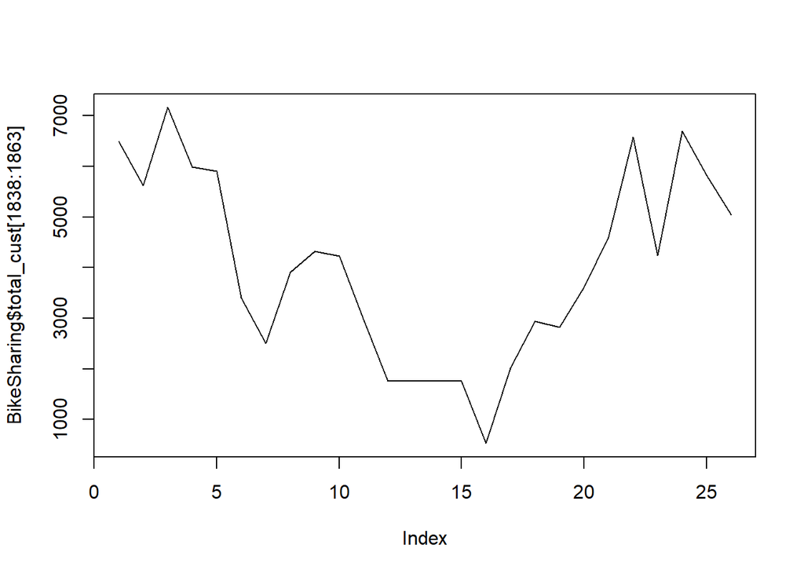

```r
# Plot around where the imputed values are
plot(BikeSharing$total_cust[1838:1863], type = "l")
```

## Plot the Data

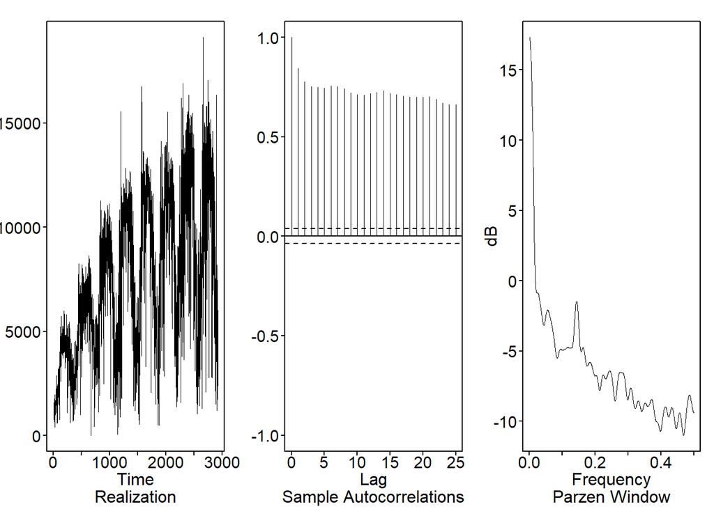

[output not shown]

[output cut: 583 more lines]

```r
# Plot the full dataset

# The realization plot shows strong periodic trends, wandering behavior, and variance that changes over time.

# We see slowly dampening autocorrelation with weak and an irregular length periodic behavior.

# There is a peak at zero in the parzen frequency window.
# The parzen window also shows a peak around 0.15, which is a period of 1/0.15 = 6.666.
#   B/c this data is collected daily, there evidence to suggest a weekly trend.
#   We can hypothesize total_cust could have a greater total_cust on the weekends when all other variables are held constant.
plotts.sample.wge(BikeSharing$total_cust, arlimits = TRUE)
```

## Seeing if Lags are available

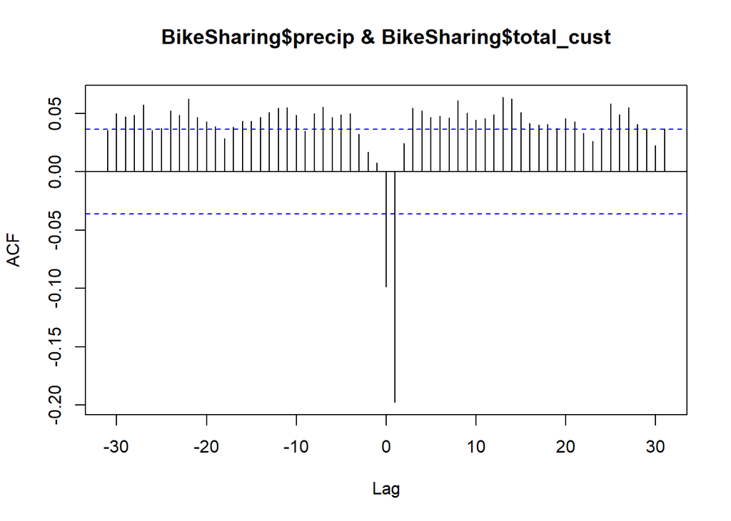

```r
# The CCF plot shows a log of 1 for precipitation. This makes sense a we might expect less people to rent a bike the day after it rains.
ccf(BikeSharing$precip, BikeSharing$total_cust)
```

```r
BikeSharing$precip_L1 = dplyr::lag(BikeSharing$precip, 1)
BikeSharing$precip_L1[is.na(BikeSharing$precip_L1)] = median(BikeSharing$precip_L1, na.rm = TRUE)
```

## Checking For MCAR

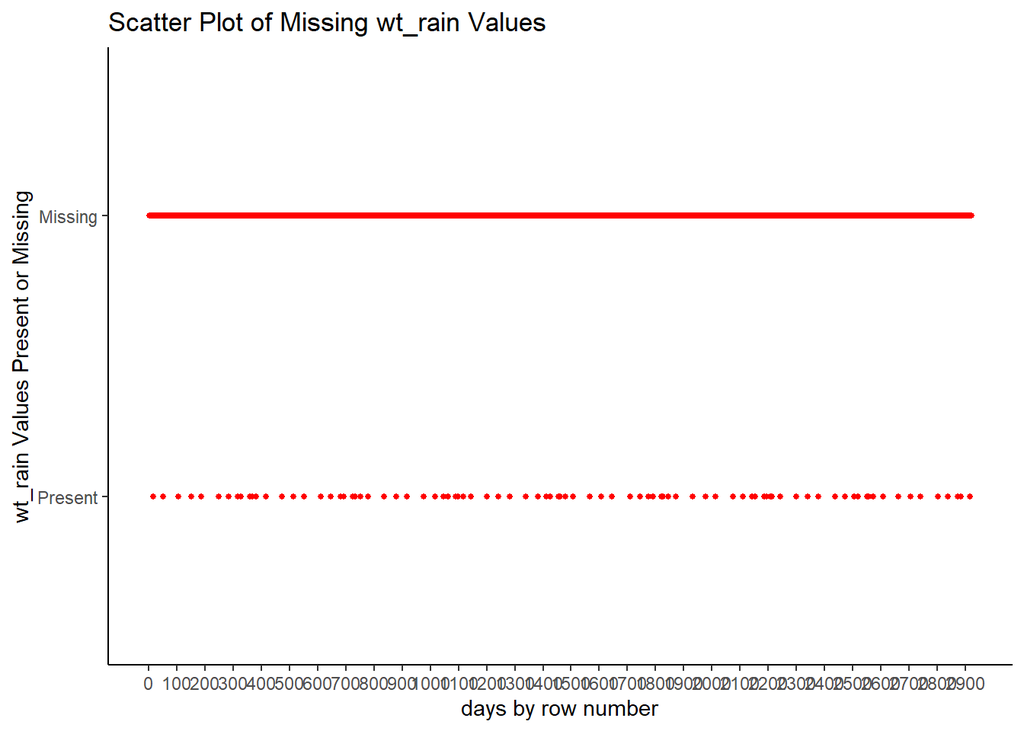

```r
# Shows the present and missing values are represented consistently throughout the plot, giving evidence the NA value can be translated to 0 and be interpreted as non holidays.
data <- data.frame(x = is.na(BikeSharing$holiday))
gg = ggplot(data, aes(x = 1:nrow(data), y = x)) +
  geom_point(size = 1, height = .5, width = .5, color = "red") +
  xlab("days by row number") +
 ylab("wt_rain Values Present or Missing") +
 labs(title = "Scatter Plot of Missing wt_rain Values", size = 10) +
 scale_y_discrete(labels = c("Present", "Missing")) +
 scale_x_continuous(breaks = seq(0, nrow(data), by = 100)) +
 theme(axis.text.x = element_text(angle = 90, hjust  = 1)) +
 theme_classic()
gg
```

```r
# Replace NA with 0 which represents non holidays, 1 represents holidays
BikeSharing$holiday = replace_na(BikeSharing$holiday, 0)
head(BikeSharing$holiday)
```

```
## [1] 0 0 0 0 0 0
```

## Explore correlations for the data

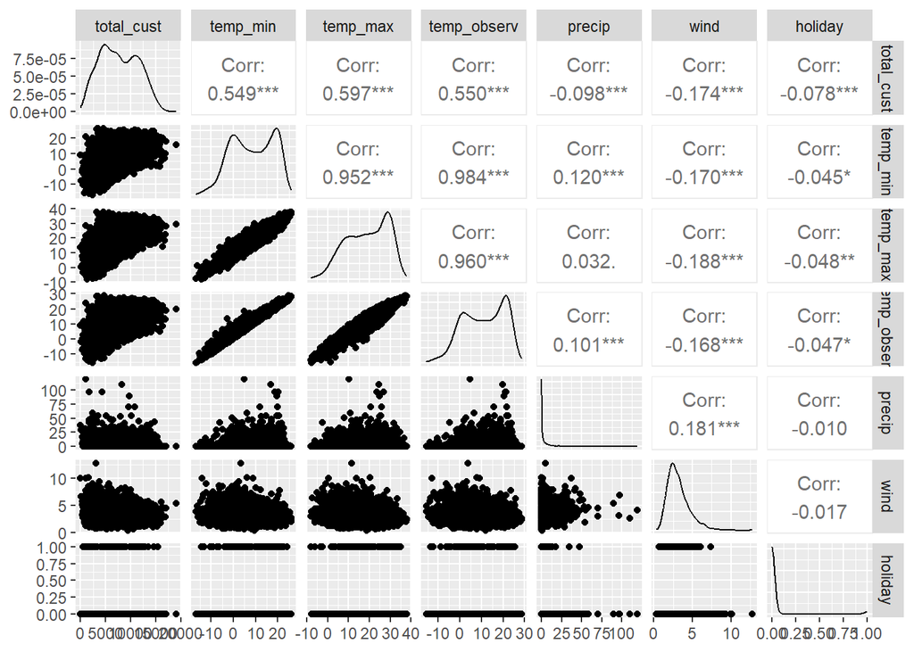

```r
ggpairs(BikeSharing[, c(28,3,4,5,6,7,29)])
```

We will try to experiment to estimate for candidate AR or ARMA model based on AIC and BIC values here. We can observe that AN AR(8) model was picked by both AIC AND BIC and also by the PACF function (Box and jenkins method) we saw evidence of an AR(8) as well.

```
## ---------WORKING... PLEASE WAIT...
##
##
## Five Smallest Values of  aic
##     p    q        aic
##     8    0   15.01710
##     7    0   15.02048
##     6    0   15.03340
##     5    0   15.06260
##     4    0   15.08154
```

```
## ---------WORKING... PLEASE WAIT...
##
##
## Five Smallest Values of  bic
##     p    q        bic
##     8    0   15.03552
##     7    0   15.03685
##     6    0   15.04773
##     5    0   15.07488
##     4    0   15.09177
```

### Box and Jenkins Method to identifY AR(p) using PACF function plot

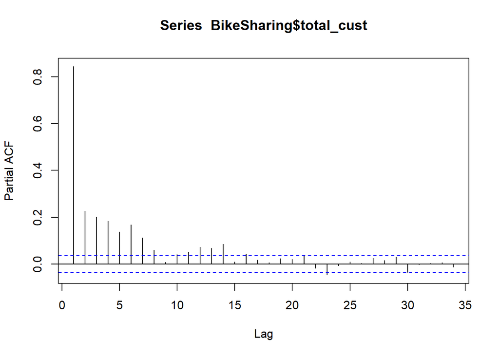

```r
pacf(BikeSharing$total_cust) # suggest an AR(8) model
```

Observe that from the code above by running the estimate for p and q for both AIC and BIC for ranges of P and Q of my choosing that make sense, I will probably go with an AR(8) since this seems to strike a balance between the AIC and BIC values.

And checking with PACF function we see evidence of an AR(8) model.

Next We will see what happens if I apply a transformation for S=7 and S=365 to see if these are useful.

I will also check for any (1-B)^d term.

Note to self: It is not a good idea to just look at the factor tables. Look at the data, look at the realizations, look at the ACFs, and look at the factor tables, and together you can gather a lot of information to find the most useful model. So before and after differencing. So you should check all these out before and after differences.

```r
# transform data
# Difference the data to until we get a stationary model to check for (1-B)^d
# we could use the Dickey-Fuller Test he to see if model as evidence for a unit root, but differencing here I do not see visual evidence for a (1-B) term.
b1=artrans.wge(BikeSharing$total_cust,phi.tr=1)
```

[figure not shown]

```r
#although the data does not look white we do see in the acf that a sinusoidal trend appears
b7=artrans.wge(BikeSharing$total_cust,phi.tr = c(rep(0,6),1))
```

[figure not shown]

From the below plots there does not seem to be evidence for a (1-B)^d So we will not include this in the model. The Autocorrelation Function (ACF) plot does not suggest white noise. In a white noise series, we would expect most of the spikes in the ACF plot to fall within the confidence interval (usually represented by blue shaded areas or dashed lines), indicating that there is no significant correlation at different lags.

However, the acf indicates that there are significant correlations at various lags. This suggests that the time series data exhibits some patterns or relationships between its values at different times, which is not characteristic of white noise.

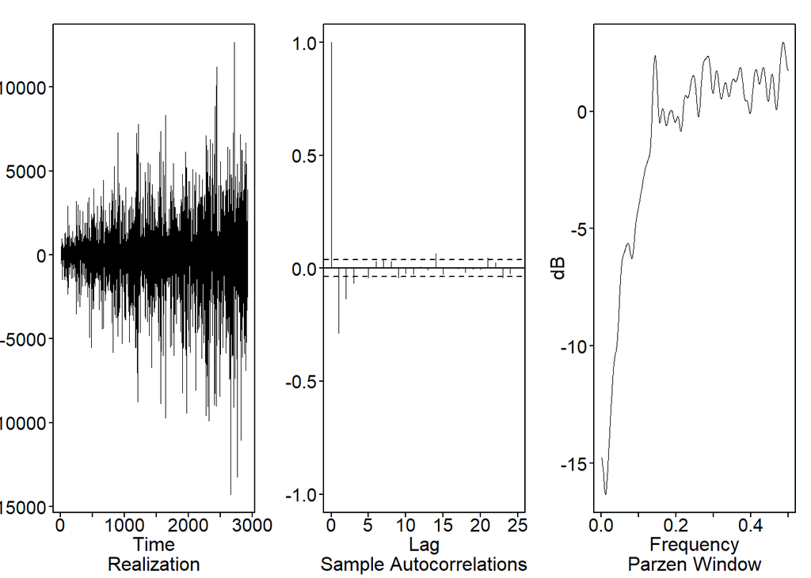

[output not shown]

[output cut: 583 more lines]

```r
plotts.sample.wge(b1, arlimits = TRUE)
```

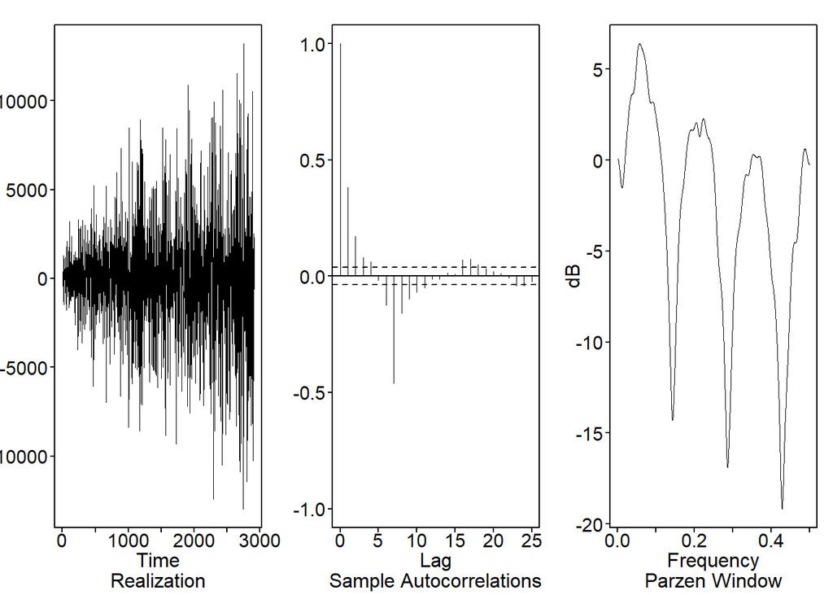

[output not shown]

[output cut: 583 more lines]

```r
plotts.sample.wge(b7, arlimits = TRUE)
```